# Maximization

Dave Clark

2022-08-21

## Technology of MLE

These slides are about the technology of ML, specifically a stylized account of how ML uses “plug-and-chug” techniques to find the vector of $\beta$ that most likely produced the data we observe.

Note that numerical methods and grid searches both are iterative in this way; the example below is aimed at showing that iterative process.

## The problem

Suppose we have three friends trying to figure out whether to eat out at a Chinese buffet, or a Tex-Mex restaurant. They agree to toss coins to decide - heads is Chinese, tails is Tex-Mex. Each friend tosses a coin - whatever gets the majority wins.

## The problem

These 3 friends each toss a coin to solve this important problem; 2 come up heads. The data look like this:

Data on Coin Tosses

| Toss | Heads | Tails |
| --- | --- | --- |
| Alice | 1 | 0 |
| Kathleen | 0 | 1 |
| Elizabeth | 1 | 0 |

The core ML question is: **“What is the parameter that most likely generated these data?”**

## Characterizing the DGP

Let’s start by thinking about the data generating process (DGP) - each coin toss can take either of two values. So these sound like Bernoulli trials. Here’s the Bernoulli PDF:

$$p^h * (1-p)^{(N-h)}$$
So the probability of a heads raised to the number of heads, times the probability of a tails raised to the number of tails (total tosses minus heads).

## Grid Search

$h$ is known; so is $N-h$. The unknown is $p$, the parameter that produced the data we observed (2 heads, 1 tails).

We know $p$ lies in the $(0,1)$ interval, so what if we plug all the values in that interval into the Bernoulli PDF, and see which value of $p$ produces the highest likelihood value - that $p$ is the one that has the highest likelihood of having produced these data.

## Plug and Chug

Here’s (familiar looking) code to evaluate this question:

```r
like <- NULL
pr <- NULL

for (p in seq(1,100,1)) {
  l <- (p/100)^2 * (1-(p/100))^1
  like[p] <- l
  pr[p] <- p/100
}

df <-data.frame(like,pr)

# ggplot(df, aes(x=pr, y=like)) +
#   geom_line() +
#   geom_vline(aes(xintercept = pr),
#              data=df %>% filter(like==max(like)), color="red")
```

## Grid Search Plot

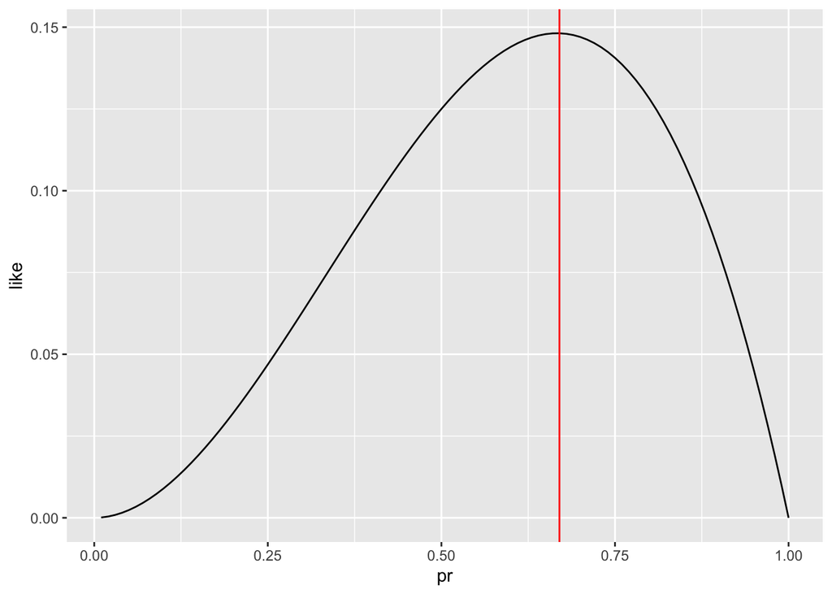